# The scrambled experiment (EEG, Maffei)

```r
# library(readr)
#
# file_list=dir("ERPDataSingleTrialforstudents",full.names = TRUE)
# temp=lapply(file_list,read_table)
#
# str(temp)
# D=do.call(rbind,temp)
#
# D = D[,c("PO7", "PO8","ID", "Condition")]
#
# ##equivalent to:
# #library(dplyr)
# ##select columns by name
# #D = D %>%  select(PO7, PO8,ID, Condition)
#
# library(tidyr)
#
# # The arguments to gather():
# # - data: Data object
# # - key: Name of new key column (made from names of data columns)
# # - value: Name of new value column
# # - ...: Names of source columns that contain values
# # - factor_key: Treat the new key column as a factor (instead of character vector)
# D <- gather(D, Channel, Mean_Amplitude, PO7:PO8,factor_key=TRUE)
#
# write_csv(D,file = "data_eeg_scrambled.csv")

library(readr)
D=read.csv("data_eeg_scrambled.csv",stringsAsFactors = TRUE)
str(D)
```

```
## 'data.frame':    21840 obs. of  4 variables:
##  $ ID            : int  1 1 1 1 1 1 1 1 1 1 ...
##  $ Condition     : Factor w/ 4 levels "Cars","Faces",..: 1 1 1 4 2 3 3 3 4 2 ...
##  $ Channel       : Factor w/ 2 levels "PO7","PO8": 1 1 1 1 1 1 1 1 1 1 ...
##  $ Mean_Amplitude: num  11.714 8.054 10.427 -0.965 -2.752 ...
```

# Fit a model

```r
library(lmerTest)
contrasts(D$Channel)=contr.sum


# Fit the mixed model
model <- lmer(Mean_Amplitude ~ Condition * Channel + (0+Condition|ID)+(0+Channel|ID), data = D)
# It doesn't converge., try a simpler model:
model <- lmer(Mean_Amplitude ~ Condition * Channel + (0+Condition|ID), data = D)
# Model summary
summary(model)
```

```
## Linear mixed model fit by REML. t-tests use Satterthwaite's method [
## lmerModLmerTest]
## Formula: Mean_Amplitude ~ Condition * Channel + (0 + Condition | ID)
##    Data: D
##
## REML criterion at convergence: 149946.5
##
## Scaled residuals:
##     Min      1Q  Median      3Q     Max
## -6.7246 -0.6212 -0.0215  0.5995  5.9670
##
## Random effects:
##  Groups   Name                    Variance Std.Dev. Corr
##  ID       ConditionCars           17.73    4.211
##           ConditionFaces          25.25    5.025    0.69
##           ConditionScrambledCars  23.14    4.810    0.62 0.84
##           ConditionScrambledFaces 26.61    5.158    0.53 0.81 0.98
##  Residual                         54.95    7.413
## Number of obs: 21840, groups:  ID, 40
##
## Fixed effects:
##                                    Estimate Std. Error         df t value
## (Intercept)                       5.896e-01  6.734e-01  3.903e+01   0.876
## ConditionFaces                    1.738e+00  6.035e-01  3.921e+01   2.879
## ConditionScrambledCars            5.801e+00  6.437e-01  3.892e+01   9.012
## ConditionScrambledFaces           7.114e+00  7.442e-01  3.901e+01   9.559
## Channel1                          7.274e-02  1.004e-01  2.167e+04   0.724
## ConditionFaces:Channel1          -3.731e-01  1.416e-01  2.167e+04  -2.636
## ConditionScrambledCars:Channel1  -4.069e-01  1.419e-01  2.167e+04  -2.866
## ConditionScrambledFaces:Channel1 -5.678e-01  1.422e-01  2.167e+04  -3.991
##                                  Pr(>|t|)
## (Intercept)                       0.38665
## ConditionFaces                    0.00643 **
## ConditionScrambledCars           4.55e-11 ***
## ConditionScrambledFaces          9.02e-12 ***
## Channel1                          0.46883
## ConditionFaces:Channel1           0.00841 **
## ConditionScrambledCars:Channel1   0.00416 **
## ConditionScrambledFaces:Channel1 6.59e-05 ***
## ---
## Signif. codes:  0 '***' 0.001 '**' 0.01 '*' 0.05 '.' 0.1 ' ' 1
##
## Correlation of Fixed Effects:
##             (Intr) CndtnF CndtSC CndtSF Chnnl1 CnF:C1 CSC:C1
## ConditinFcs -0.214
## CndtnScrmbC -0.322  0.727
## CndtnScrmbF -0.331  0.727  0.959
## Channel1     0.000  0.000  0.000  0.000
## CndtnFcs:C1  0.000  0.000  0.000  0.000 -0.709
## CndtnScC:C1  0.000  0.000  0.000  0.000 -0.707  0.502
## CndtnScF:C1  0.000  0.000  0.000  0.000 -0.706  0.501  0.499
## optimizer (nloptwrap) convergence code: 0 (OK)
## Model failed to converge with max|grad| = 0.00263395 (tol = 0.002, component 1)
```

```r
# ANOVA of the model
car::Anova(model)
```

```
## Analysis of Deviance Table (Type II Wald chisquare tests)
##
## Response: Mean_Amplitude
##                     Chisq Df Pr(>Chisq)
## Condition         126.701  3  < 2.2e-16 ***
## Channel            27.687  1  1.426e-07 ***
## Condition:Channel  17.125  3  0.0006661 ***
## ---
## Signif. codes:  0 '***' 0.001 '**' 0.01 '*' 0.05 '.' 0.1 ' ' 1
```

```r
# Post-hoc analysis using emmeans
library(emmeans)
emmeans_result <- emmeans(model, pairwise ~ Condition | Channel)
```

```
## Note: D.f. calculations have been disabled because the number of observations exceeds 3000.
## To enable adjustments, add the argument 'pbkrtest.limit = 21840' (or larger)
## [or, globally, 'set emm_options(pbkrtest.limit = 21840)' or larger];
## but be warned that this may result in large computation time and memory use.
```

```
## Note: D.f. calculations have been disabled because the number of observations exceeds 3000.
## To enable adjustments, add the argument 'lmerTest.limit = 21840' (or larger)
## [or, globally, 'set emm_options(lmerTest.limit = 21840)' or larger];
## but be warned that this may result in large computation time and memory use.
```

```r
summary(emmeans_result)
```

```
## $emmeans
## Channel = PO7:
##  Condition      emmean    SE  df asymp.LCL asymp.UCL
##  Cars            0.662 0.681 Inf    -0.672      2.00
##  Faces           2.027 0.809 Inf     0.442      3.61
##  ScrambledCars   6.057 0.774 Inf     4.540      7.57
##  ScrambledFaces  7.208 0.828 Inf     5.585      8.83
##
## Channel = PO8:
##  Condition      emmean    SE  df asymp.LCL asymp.UCL
##  Cars            0.517 0.681 Inf    -0.818      1.85
##  Faces           2.628 0.809 Inf     1.043      4.21
##  ScrambledCars   6.725 0.774 Inf     5.208      8.24
##  ScrambledFaces  8.198 0.828 Inf     6.576      9.82
##
## Degrees-of-freedom method: asymptotic
## Confidence level used: 0.95
##
## $contrasts
## Channel = PO7:
##  contrast                       estimate    SE  df z.ratio p.value
##  Cars - Faces                      -1.36 0.620 Inf  -2.201  0.1229
##  Cars - ScrambledCars              -5.39 0.659 Inf  -8.183  <.0001
##  Cars - ScrambledFaces             -6.55 0.758 Inf  -8.639  <.0001
##  Faces - ScrambledCars             -4.03 0.483 Inf  -8.338  <.0001
##  Faces - ScrambledFaces            -5.18 0.534 Inf  -9.707  <.0001
##  ScrambledCars - ScrambledFaces    -1.15 0.264 Inf  -4.369  0.0001
##
## Channel = PO8:
##  contrast                       estimate    SE  df z.ratio p.value
##  Cars - Faces                      -2.11 0.620 Inf  -3.405  0.0037
##  Cars - ScrambledCars              -6.21 0.659 Inf  -9.418  <.0001
##  Cars - ScrambledFaces             -7.68 0.758 Inf -10.138  <.0001
##  Faces - ScrambledCars             -4.10 0.483 Inf  -8.478  <.0001
##  Faces - ScrambledFaces            -5.57 0.534 Inf -10.437  <.0001
##  ScrambledCars - ScrambledFaces    -1.47 0.264 Inf  -5.590  <.0001
##
## Degrees-of-freedom method: asymptotic
## P value adjustment: tukey method for comparing a family of 4 estimates
```

## Plotting tools

for the first model:

```r
library(effects)
```

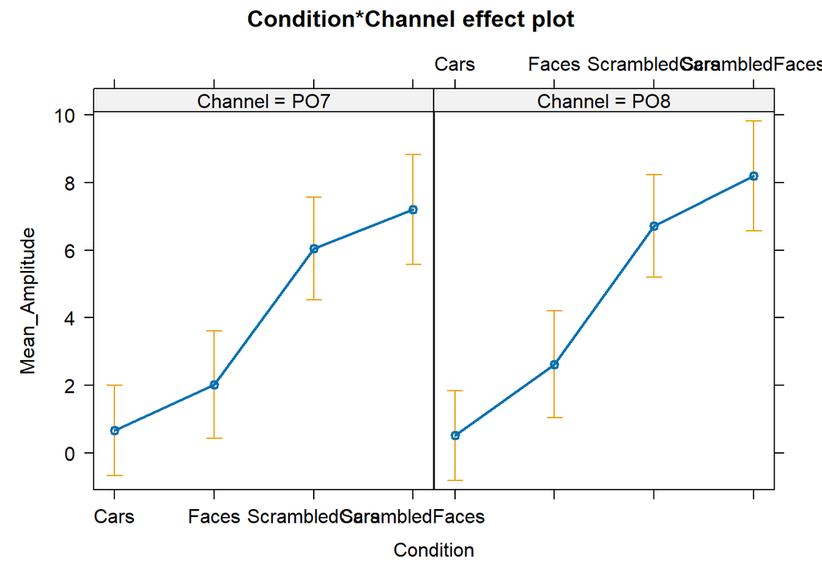

```r
plot(allEffects(model))
```

```r
#plot random effects:
require(lattice)
#qqmath(ranef(model, condVar=TRUE))
```

An alternative plotting tool:

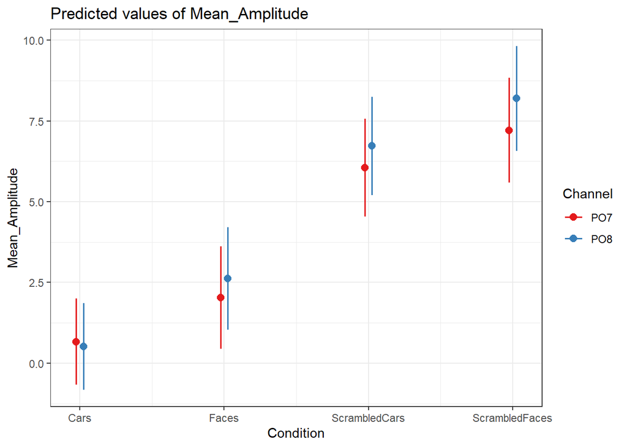

```r
library(sjPlot)
library(ggplot2)
plot_model(model, type = "pred", terms = c("Condition", "Channel"))+theme_bw()
```

# A different parametrization

Let’s use a different encoding fo `Condition`, it may be more informative…

```r
D$Scrambled="N"
D$Scrambled[grep("Scrambled",D$Condition)]="Y"
D$Scrambled=factor(D$Scrambled)
contrasts(D$Scrambled)<- contr.sum
#   [,1]
# N    1
# Y   -1

D$Content="Face"
D$Content[grep("Cars",D$Condition)]="Car"
D$Content=factor(D$Content)
contrasts(D$Content)<- contr.sum
#      [,1]
# Car     1
# Face   -1

# Furthermore, for Channel:
#      [,1]
# PO7     1
# PO8    -1


#IMPORTANT: CREATE new vars: two-level factors in +1, -1 contrast variables:
D$Content_=model.matrix(~1+Content,D)[,2]
D$Scrambled_=model.matrix(~1+Scrambled,D)[,2]
D$Channel_=model.matrix(~1+Channel,D)[,2]

# Fit the mixed model
model <- lmer(Mean_Amplitude ~ Scrambled * Content * Channel +
                 (1+Scrambled_+Content_+Channel_||ID), data = D)


# Model summary
summary(model)
```

```
## Linear mixed model fit by REML. t-tests use Satterthwaite's method [
## lmerModLmerTest]
## Formula: Mean_Amplitude ~ Scrambled * Content * Channel + (1 + Scrambled_ +
##     Content_ + Channel_ || ID)
##    Data: D
##
## REML criterion at convergence: 149357.5
##
## Scaled residuals:
##     Min      1Q  Median      3Q     Max
## -6.5407 -0.6090 -0.0132  0.5886  6.2355
##
## Random effects:
##  Groups   Name        Variance Std.Dev.
##  ID       (Intercept) 18.809   4.337
##  ID.1     Scrambled_   2.486   1.577
##  ID.2     Content_     1.149   1.072
##  ID.3     Channel_     2.401   1.550
##  Residual             53.204   7.294
## Number of obs: 21840, groups:  ID, 40
##
## Fixed effects:
##                                Estimate Std. Error         df t value Pr(>|t|)
## (Intercept)                   4.252e+00  6.875e-01  3.899e+01   6.184 2.88e-07
## Scrambled1                   -2.797e+00  2.543e-01  3.875e+01 -11.002 1.74e-13
## Content1                     -7.642e-01  1.767e-01  3.918e+01  -4.325 0.000102
## Channel1                     -2.864e-01  2.500e-01  3.913e+01  -1.145 0.258990
## Scrambled1:Content1          -1.198e-01  4.982e-02  2.174e+04  -2.405 0.016198
## Scrambled1:Channel1           1.547e-01  4.943e-02  2.168e+04   3.129 0.001755
## Content1:Channel1             1.390e-01  4.942e-02  2.168e+04   2.813 0.004912
## Scrambled1:Content1:Channel1  5.715e-02  4.944e-02  2.168e+04   1.156 0.247728
##
## (Intercept)                  ***
## Scrambled1                   ***
## Content1                     ***
## Channel1
## Scrambled1:Content1          *
## Scrambled1:Channel1          **
## Content1:Channel1            **
## Scrambled1:Content1:Channel1
## ---
## Signif. codes:  0 '***' 0.001 '**' 0.01 '*' 0.05 '.' 0.1 ' ' 1
##
## Correlation of Fixed Effects:
##              (Intr) Scrmb1 Cntnt1 Chnnl1 Scrmbld1:Cn1 Scrmbld1:Ch1 Cn1:C1
## Scrambled1    0.000
## Content1      0.000  0.000
## Channel1      0.000  0.000  0.000
## Scrmbld1:Cn1 -0.001 -0.002  0.003  0.000
## Scrmbld1:Ch1  0.000  0.000  0.000 -0.001  0.000
## Cntnt1:Chn1   0.000  0.000  0.000  0.000  0.000        0.003
## Scrm1:C1:C1   0.000  0.000  0.000  0.001  0.000       -0.001       -0.002
```

```r
# ANOVA of the model
car::Anova(model)
```

```
## Analysis of Deviance Table (Type II Wald chisquare tests)
##
## Response: Mean_Amplitude
##                              Chisq Df Pr(>Chisq)
## Scrambled                 121.1599  1  < 2.2e-16 ***
## Content                    18.6501  1   1.57e-05 ***
## Channel                     1.3106  1   0.252281
## Scrambled:Content           5.7822  1   0.016189 *
## Scrambled:Channel           9.8007  1   0.001744 **
## Content:Channel             7.9279  1   0.004868 **
## Scrambled:Content:Channel   1.3361  1   0.247715
## ---
## Signif. codes:  0 '***' 0.001 '**' 0.01 '*' 0.05 '.' 0.1 ' ' 1
```

```r
# Post-hoc analysis using emmeans
require(emmeans)
emmeans_result <- emmeans(model, pairwise ~ Content | Channel*Scrambled)
```

```
## Note: D.f. calculations have been disabled because the number of observations exceeds 3000.
## To enable adjustments, add the argument 'pbkrtest.limit = 21840' (or larger)
## [or, globally, 'set emm_options(pbkrtest.limit = 21840)' or larger];
## but be warned that this may result in large computation time and memory use.
```

```
## Note: D.f. calculations have been disabled because the number of observations exceeds 3000.
## To enable adjustments, add the argument 'lmerTest.limit = 21840' (or larger)
## [or, globally, 'set emm_options(lmerTest.limit = 21840)' or larger];
## but be warned that this may result in large computation time and memory use.
```

```r
summary(emmeans_result)
```

```
## $emmeans
## Channel = PO7, Scrambled = N:
##  Content emmean    SE  df asymp.LCL asymp.UCL
##  Car      0.635 0.801 Inf    -0.934      2.20
##  Face     2.010 0.801 Inf     0.441      3.58
##
## Channel = PO8, Scrambled = N:
##  Content emmean    SE  df asymp.LCL asymp.UCL
##  Car      0.506 0.801 Inf    -1.063      2.07
##  Face     2.666 0.801 Inf     1.097      4.24
##
## Channel = PO7, Scrambled = Y:
##  Content emmean    SE  df asymp.LCL asymp.UCL
##  Car      6.045 0.800 Inf     4.476      7.61
##  Face     7.170 0.801 Inf     5.601      8.74
##
## Channel = PO8, Scrambled = Y:
##  Content emmean    SE  df asymp.LCL asymp.UCL
##  Car      6.763 0.800 Inf     5.195      8.33
##  Face     8.216 0.801 Inf     6.647      9.79
##
## Degrees-of-freedom method: asymptotic
## Confidence level used: 0.95
##
## $contrasts
## Channel = PO7, Scrambled = N:
##  contrast   estimate    SE  df z.ratio p.value
##  Car - Face    -1.38 0.393 Inf  -3.500  0.0005
##
## Channel = PO8, Scrambled = N:
##  contrast   estimate    SE  df z.ratio p.value
##  Car - Face    -2.16 0.393 Inf  -5.496  <.0001
##
## Channel = PO7, Scrambled = Y:
##  contrast   estimate    SE  df z.ratio p.value
##  Car - Face    -1.13 0.393 Inf  -2.865  0.0042
##
## Channel = PO8, Scrambled = Y:
##  contrast   estimate    SE  df z.ratio p.value
##  Car - Face    -1.45 0.393 Inf  -3.699  0.0002
##
## Degrees-of-freedom method: asymptotic
```

## Plotting tools

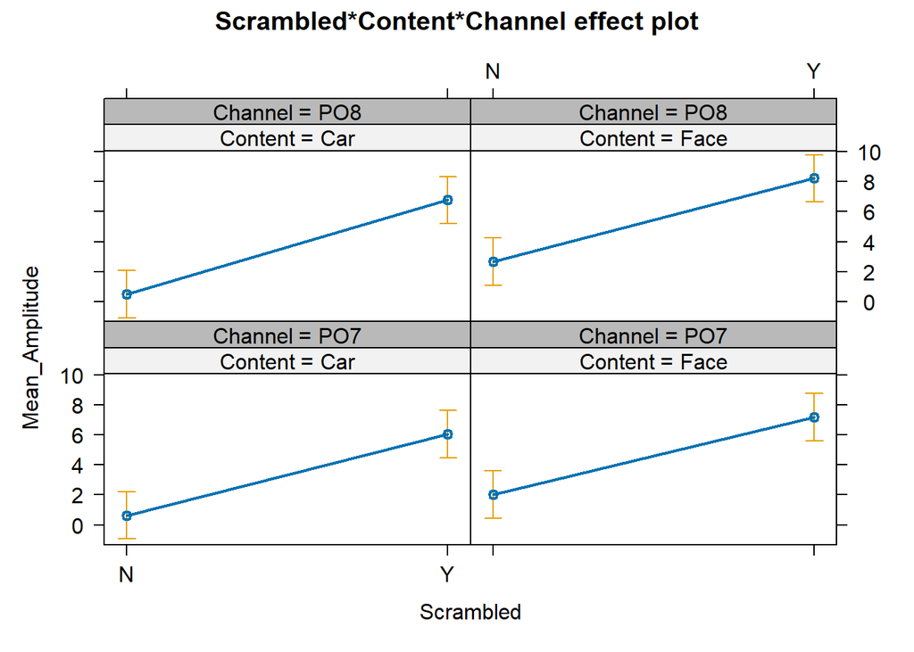

```r
library(effects)
plot(allEffects(model))
```

```r
#plot random effects:
require(lattice)
# qqmath(ranef(model, condVar=TRUE))
```

An alternative plotting tool:

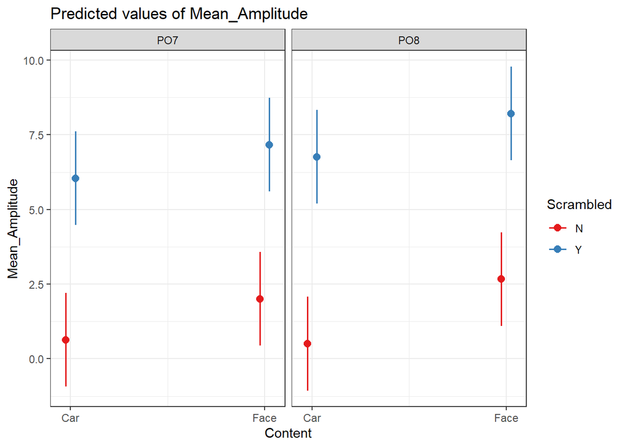

```r
library(sjPlot)
library(ggplot2)
plot_model(model, type = "pred", terms = c("Content","Scrambled", "Channel"))+theme_bw()
```

# What random structure to set?

the followint is entirelly taken from: Winter (2013)

*There are a few important things to say here: You might ask yourself “Which random slopes should I specify?” … or even “Are random slopes necessary at all?” A lot of people construct random intercept-only models but conceptually, it makes a hella sense to include random slopes most of the time. After all, you can almost always expect that people differ with how they react to an experimental manipulation! And likewise, you can almost always expect that the effect of an experimental manipulation is not going to be the same for all items.*

*Moreover, researchers in ecology (Schielzeth & Forstmeier, 2009), psycholinguistics (Barr, Levy, Scheepers, & Tilly, 2013) and other fields have shown via simulations that mixed models without random slopes are anticonservative or, in other words, they have a relatively high Type I error rate (they tend to find a lot of significant results which are actually due to chance).*

*Barr et al. (2013) recommend that you should “keep it maximal” with respect to your random effects structure, at least for controlled experiments. This means that you include all random slopes that are justified by your experimental design … and you do this for all fixed effects that are important for the overall interpretation of your study.*

Setting up the random effects structure can be very tricky, but some recommendations can be still given:

1. Start with theory: Consider which variables in your design could reasonably have random effects based on your experimental design and knowledge of the subject matter.
2. Maximal random effects structure: As a starting point, try to include all random effects that are justified by your design. This approach, suggested by Barr et al. (2013), helps to avoid Type I errors.
3. Keep it parsimonious: While a maximal structure is ideal, it may not always converge. If you face convergence issues, simplify the structure step by step.
4. Use model comparison: Compare models with different random effects structures using likelihood ratio tests or information criteria (AIC, BIC).
5. Consider your sample size: The number of levels in your random effects should be sufficient (usually >5-6) to estimate variance components reliably.
6. Check for overfitting: Be cautious of models that perfectly fit the data, as they might be overfit.
7. Use tools like ‘keepef’ function in R: This can help identify which random effects contribute significantly to the model.

Remember, there’s often a balance between a complex, theoretically justified structure and a simpler one that actually converges. It’s a bit of an art as well as a science!

https://keithlohse.github.io/mixed_effects_models/lohse_MER_section_03_factorial.html https://courses.washington.edu/psy524a/_book/linear-mixed-models.html